# APIs

Korn Ferry Institute

3/25/2019

## Simple APIs

We’ll start with using an **API** or **A**pplication **P**rogram **I**nterface.

An API is effectivelly a toolkit that someone makes to help other people work with software. Put simply, an API (hopefully) takes out the mess and headaches of trying to get two programs to work together nicely. Companies like Microsoft, Twitter, Amazon Web Services, Facebook, and Linkedin provide APIs to help people interface with their online services in a controlled way.

Many online APIs allow for external applications to access information from a services as though they were logged into that service without sharing user or password information with the external application. This is typically done with OAuth, which allows the server to provide access tokens to these external application.

Setting up an application to use an API typically involves the following steps: 1. Logging into the developer site. 2. Adding an application and determining user permissions. 3. Extracting the consumer key and the consumer secret, which is how the application (not the user) identifies itself to the service. 4. Logging into the service to obtain the access token and access secret, which is how the user (not the application) identifies itself to the service.

With the consumer key/secret and the access token/secret, one can access the API as an application for a particular user without sharing passwords.

In this tutorial, we will use Twitter’s API due to its simplicity and well developed `R` packages.

The following steps will get you started:

- Log into your Twitter account and go to https://developer.twitter.com/
- Apply for an account and request access for personal use. Fill out all of the information in this section (it can be long).
- Click on the button **Create an app**
  - Click on the **Create an app** button (in blue)
  - Put all of the required information:
    - App name
    - App description
    - Website URL
    - Callback URL: http://127.0.0.1:1410
- Obtain consumer keys and tokens (copy)

```r
consumer_key    <- "wDlJPoKnmrrGqAwBOSkQi8OEN"
consumer_secret <- "ONsG3G1qLAuaDFnZlXIIsK9T3v9rESDOo0cl5ECZvAiOqW3eu0"
```

- Obtain access token and secret (I’ve saved these in environment variables)

```r
access_token    <- Sys.getenv("TWITTER_TOKEN")
access_secret   <- Sys.getenv("TWITTER_SECRET")
if(nchar(access_token) == 0){
  access_token  <- NULL
}
if(nchar(access_secret) == 0){
  access_secret <- NULL
}
```

Now you’re ready to use your new API key.

You’ll need the package `rtweet`, which is designed to make API calls easy to parse and return. We will also get `ggplot2`, `ggthemes`, and `dplyr` for later data parsing and plotting. Use `rtweet` to create an oAuth object to authorize use for the app. If your `access_token` or `access_secret` is missing, your browser will ask you to authorize the access request for your app.

```r
require(rtweet)
require(ggplot2)
require(ggthemes)
require(dplyr)
```

```r
token <- create_token(
  consumer_key    = consumer_key,    # for the app
  consumer_secret = consumer_secret, # for the app
  access_token    = access_token,    # for the user
  access_secret   = access_secret,   # for the user
  set_renv        = FALSE            # update environment variables
)
```

Note that if you let `set_renv = TRUE`, then your environment variable will be updated so that your token will automatically be read in future versions of your data analysis and you don’t need to run this function again.

Now that we’re authorized, we can do a simple search for tweets. Given the conference, we should see the total number of recent tweets (in the last 7 days) for “#SIOP19”. Note that `rtweet` only searches tweets in the last 7-9 days, and free accounts only allow unlimited access to tweets in the last 7 days (from what I can tell, although they may change permissions soon).

```r
tweets <- search_tweets(
  q           = "#SIOP19", # the search string
  include_rts = FALSE,     # retweets?
  token       = token
)
```

```
## Searching for tweets...
```

```
## Finished collecting tweets!
```

```r
tweets
```

```
## # A tibble: 99 x 88
##    user_id status_id created_at          screen_name text  source
##  * <chr>   <chr>     <dttm>              <chr>       <chr> <chr>
##  1 125368… 11113723… 2019-03-28 21:00:00 talentkeep… "Loo… Tweet…
##  2 125368… 11109647… 2019-03-27 18:00:01 talentkeep… "Loo… Tweet…
##  3 125368… 11106876… 2019-03-26 23:39:00 talentkeep… "Loo… Tweet…
##  4 581346… 11113717… 2019-03-28 20:57:21 ProfSearle  Soun… Twitt…
##  5 224851… 11113685… 2019-03-28 20:44:45 Rob_Briner  "If … Twitt…
##  6 277610… 11110477… 2019-03-27 23:30:04 SIOPtweets  What… Hoots…
##  7 277610… 11113573… 2019-03-28 20:00:24 SIOPtweets  Plat… Hoots…
##  8 277610… 11113661… 2019-03-28 20:35:06 SIOPtweets  Earn… Hoots…
##  9 277610… 11113219… 2019-03-28 17:39:40 SIOPtweets  Wher… Insta…
## 10 277610… 11110176… 2019-03-27 21:30:28 SIOPtweets  Than… Hoots…
## # ... with 89 more rows, and 82 more variables: display_text_width <dbl>,
## #   reply_to_status_id <chr>, reply_to_user_id <chr>,
## #   reply_to_screen_name <chr>, is_quote <lgl>, is_retweet <lgl>,
## #   favorite_count <int>, retweet_count <int>, hashtags <list>,
## #   symbols <list>, urls_url <list>, urls_t.co <list>,
## #   urls_expanded_url <list>, media_url <list>, media_t.co <list>,
## #   media_expanded_url <list>, media_type <list>, ext_media_url <list>,
## #   ext_media_t.co <list>, ext_media_expanded_url <list>,
## #   ext_media_type <chr>, mentions_user_id <list>,
## #   mentions_screen_name <list>, lang <chr>, quoted_status_id <chr>,
## #   quoted_text <chr>, quoted_created_at <dttm>, quoted_source <chr>,
## #   quoted_favorite_count <int>, quoted_retweet_count <int>,
## #   quoted_user_id <chr>, quoted_screen_name <chr>, quoted_name <chr>,
## #   quoted_followers_count <int>, quoted_friends_count <int>,
## #   quoted_statuses_count <int>, quoted_location <chr>,
## #   quoted_description <chr>, quoted_verified <lgl>,
## #   retweet_status_id <chr>, retweet_text <chr>,
## #   retweet_created_at <dttm>, retweet_source <chr>,
## #   retweet_favorite_count <int>, retweet_retweet_count <int>,
## #   retweet_user_id <chr>, retweet_screen_name <chr>, retweet_name <chr>,
## #   retweet_followers_count <int>, retweet_friends_count <int>,
## #   retweet_statuses_count <int>, retweet_location <chr>,
## #   retweet_description <chr>, retweet_verified <lgl>, place_url <chr>,
## #   place_name <chr>, place_full_name <chr>, place_type <chr>,
## #   country <chr>, country_code <chr>, geo_coords <list>,
## #   coords_coords <list>, bbox_coords <list>, status_url <chr>,
## #   name <chr>, location <chr>, description <chr>, url <chr>,
## #   protected <lgl>, followers_count <int>, friends_count <int>,
## #   listed_count <int>, statuses_count <int>, favourites_count <int>,
## #   account_created_at <dttm>, verified <lgl>, profile_url <chr>,
## #   profile_expanded_url <chr>, account_lang <chr>,
## #   profile_banner_url <chr>, profile_background_url <chr>,
## #   profile_image_url <chr>
```

As you can see, individual tweets are in the rows of the output, which includes the users, the text, the source of the tweet, the text width, the hashtags, etc. We can make a simple plot of tweets by time using the `ts_plots` function in `rtweet` (which is a `ggplot2` wrapper).

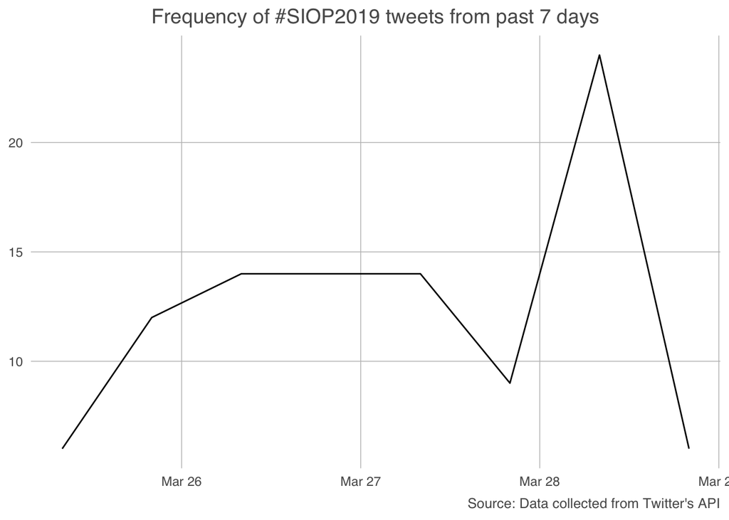

```r
ts_plot(tweets,
        by = "12 hours",
        tz = "America/New_York") +
theme_excel_new(base_size = 12,
                base_family = "sans") +
labs(title    = "Frequency of #SIOP2019 tweets from past 7 days",
     caption  = "Source: Data collected from Twitter's API")
```

We can also look up friends of particular twitter users. Because “SIOPtweets” is the official twitter of SIOP, we can find out its friends.

```r
siop_friends_id <- get_friends(users = "SIOPtweets",
                               token = token)
siop_friends_dt <- lookup_users(users = siop_friends_id$user_id,
                                token = token)
siop_friends_dt
```

```
## # A tibble: 408 x 88
##    user_id status_id created_at          screen_name text  source
##  * <chr>   <chr>     <dttm>              <chr>       <chr> <chr>
##  1 581504… 11113136… 2019-03-28 17:06:41 Bukhari_Mu… Chai… Tweet…
##  2 110088… <NA>      NA                  IshbelMcWha <NA>  <NA>
##  3 951117… 11005684… 2019-02-27 01:29:12 tkantro     @Ela… Twitt…
##  4 157021… 11112416… 2019-03-28 12:20:24 Aartideetoo Thri… Twitt…
##  5 444044… 11058052… 2019-03-13 12:18:12 jaclynmjen… DePa… Twitt…
##  6 330714… 11113402… 2019-03-28 18:52:17 acolquitt   @gra… Twitt…
##  7 101760… 11112733… 2019-03-28 14:26:29 SIOP_ECC    I ca… Twitt…
##  8 940338… 11113553… 2019-03-28 19:52:06 lisa_kath   If B… Twitt…
##  9 480264… 11105115… 2019-03-26 11:59:28 mindonthej… Prep… Twitt…
## 10 151848… 11113761… 2019-03-28 21:14:51 mikemorris… @Dan… Twitt…
## # ... with 398 more rows, and 82 more variables: display_text_width <int>,
## #   reply_to_status_id <chr>, reply_to_user_id <chr>,
## #   reply_to_screen_name <chr>, is_quote <lgl>, is_retweet <lgl>,
## #   favorite_count <int>, retweet_count <int>, hashtags <list>,
## #   symbols <list>, urls_url <list>, urls_t.co <list>,
## #   urls_expanded_url <list>, media_url <list>, media_t.co <list>,
## #   media_expanded_url <list>, media_type <list>, ext_media_url <list>,
## #   ext_media_t.co <list>, ext_media_expanded_url <list>,
## #   ext_media_type <chr>, mentions_user_id <list>,
## #   mentions_screen_name <list>, lang <chr>, quoted_status_id <chr>,
## #   quoted_text <chr>, quoted_created_at <dttm>, quoted_source <chr>,
## #   quoted_favorite_count <int>, quoted_retweet_count <int>,
## #   quoted_user_id <chr>, quoted_screen_name <chr>, quoted_name <chr>,
## #   quoted_followers_count <int>, quoted_friends_count <int>,
## #   quoted_statuses_count <int>, quoted_location <chr>,
## #   quoted_description <chr>, quoted_verified <lgl>,
## #   retweet_status_id <chr>, retweet_text <chr>,
## #   retweet_created_at <dttm>, retweet_source <chr>,
## #   retweet_favorite_count <int>, retweet_retweet_count <int>,
## #   retweet_user_id <chr>, retweet_screen_name <chr>, retweet_name <chr>,
## #   retweet_followers_count <int>, retweet_friends_count <int>,
## #   retweet_statuses_count <int>, retweet_location <chr>,
## #   retweet_description <chr>, retweet_verified <lgl>, place_url <chr>,
## #   place_name <chr>, place_full_name <chr>, place_type <chr>,
## #   country <chr>, country_code <chr>, geo_coords <list>,
## #   coords_coords <list>, bbox_coords <list>, status_url <chr>,
## #   name <chr>, location <chr>, description <chr>, url <chr>,
## #   protected <lgl>, followers_count <int>, friends_count <int>,
## #   listed_count <int>, statuses_count <int>, favourites_count <int>,
## #   account_created_at <dttm>, verified <lgl>, profile_url <chr>,
## #   profile_expanded_url <chr>, account_lang <chr>,
## #   profile_banner_url <chr>, profile_background_url <chr>,
## #   profile_image_url <chr>
```

Note that “SIOPtweets” has 408 friends. The `get_friends` function returns a `user_id` (which uniquely identifies the user), but we must use the `lookup_users` function to turn a user into a name.

If the `magick` and `webshot` packages are installed, we can create snapshots of individual tweets.

```r
# run this ONLY the first time that you are using this
webshot::install_phantomjs()
```

```r
# show the last tweet of "SIOPtweets"
img <- tweet_shot(
  statusid_or_url = filter(tweets,
                           screen_name == "SIOPtweets") %>%
                    slice(n() - 1) %>%
                    "[["("status_id")
)
print(img)
```

```
##   format width height colorspace matte filesize density
## 1    PNG   517    728       sRGB  TRUE        0   28x28
```

[figure not shown]

There are many more capabilities of the Twitter API (and APIs in general). However many of these companies (such as Twitter and LinkedIn and Facebook) restricts what users can do with the free version of the API. Because they are providing the code and the access, they can also provide limitations of individual applications.